# Modelos

Flavio Galán, Gustavo Cruz, Pedro Guzmán

2025-05-04

```
## Package 'mclust' version 6.1.1
```

```
## ✖ data.table::between()   masks dplyr::between()
## ✖ data.table::first()     masks dplyr::first()
## ✖ data.table::last()      masks dplyr::last()
## ✖ data.table::transpose() masks purrr::transpose()
```

[output not shown]

[output cut: 139 more lines]

```
## Entrenando modelo 1 (Conservador)
```

```
## Entrenando modelo 2 (Intermedio)
```

```
## Entrenando modelo 3 (Agresivo)
```

```
## [1] "Tabla de métricas de los tres modelos:"
##               MAE       RMSE        R2
## Model1 0.13438507 0.27118048 0.8307047
## Model2 0.01415812 0.09601712 0.9787761
## Model3 0.01203343 0.08239345 0.9843716
```

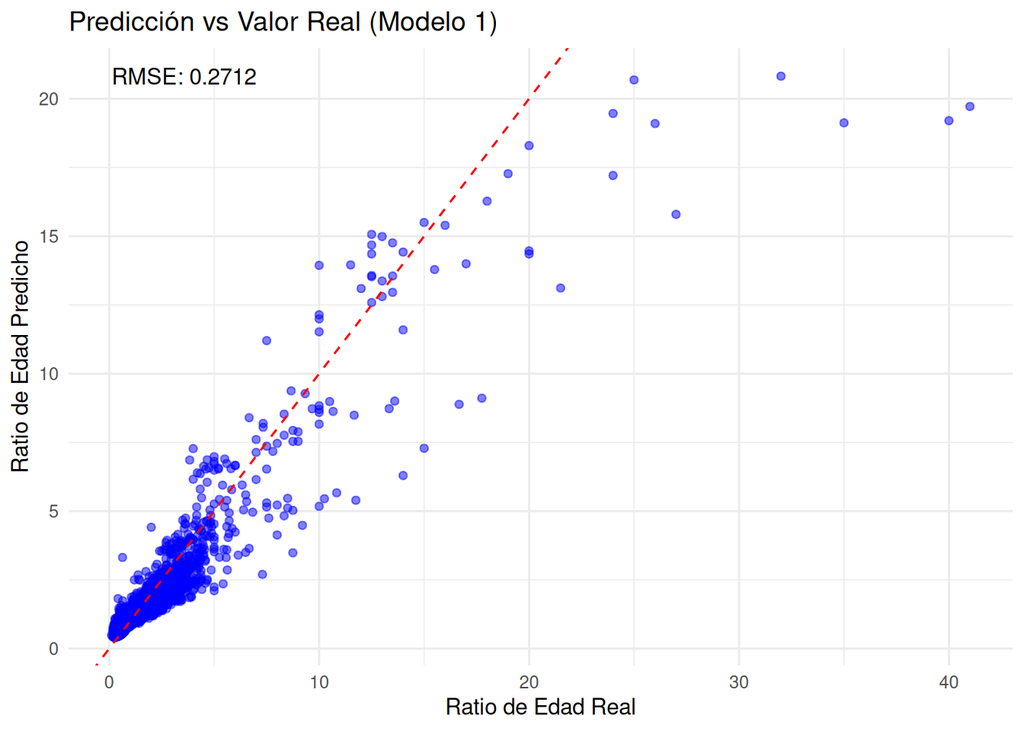

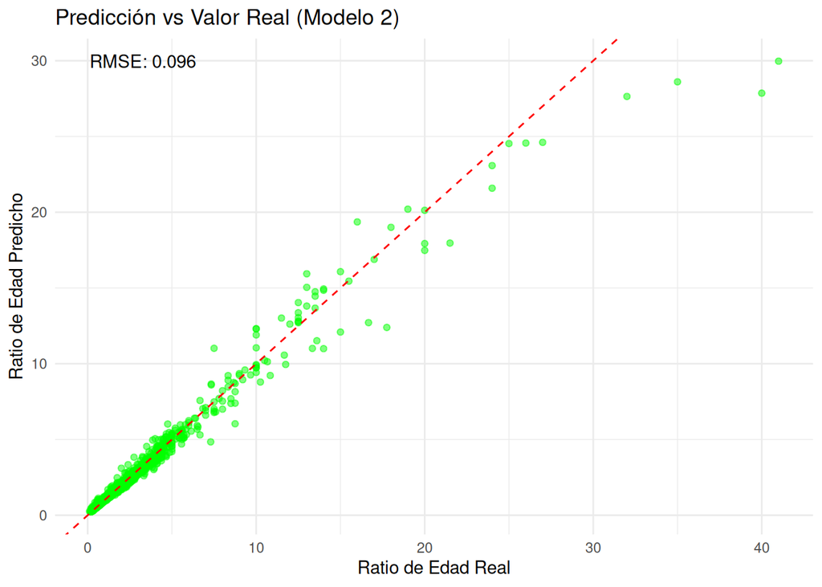

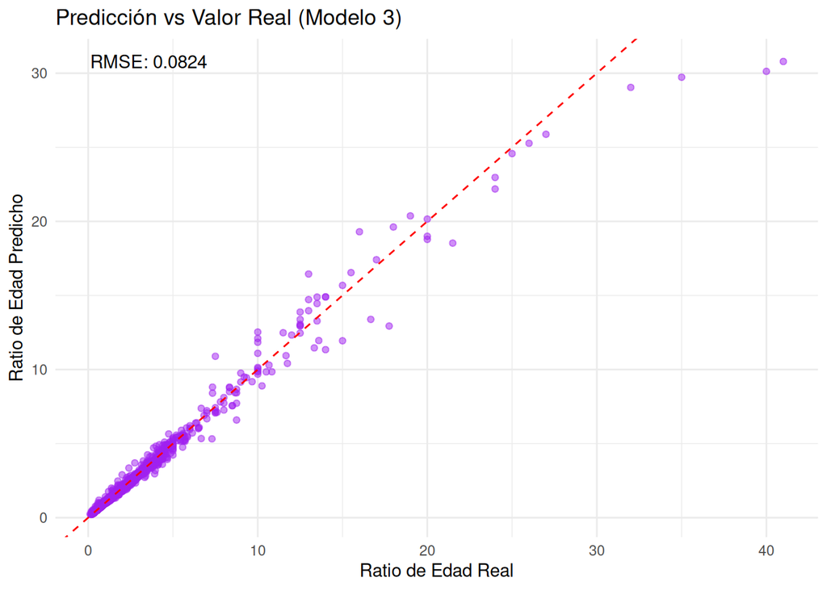

## Resultados de los modelos

La elección de estos parámetros se basó en la búsqueda de un equilibrio entre la capacidad del modelo para capturar patrones complejos en los datos y la necesidad de evitar el sobreajuste. El Modelo 1, al ser más conservador, probablemente incurrió en un mayor sesgo al no permitir suficiente flexibilidad en el aprendizaje. Los Modelos 2 y 3, al aumentar la complejidad, más árboles y más variables consideradas en cada división, lograron reducir significativamente el error.

```
## El mejor modelo es Modelo 3 con RMSE = 0.082393450121346
```

```
## Entrenando modelo FINAL con parámetros optimizados
```

```
## Resultados del modelo FINAL:
```

```
##        MAE       RMSE         R2
## 0.01199395 0.08211598 0.98447672
```

```
## [1] "Comparación entre el mejor modelo inicial y el modelo final:"
##                                MAE       RMSE        R2
## Mejor Modelo Inicial    0.01203343 0.08239345 0.9843716
## Modelo Final Optimizado 0.01199395 0.08211598 0.9844767
```

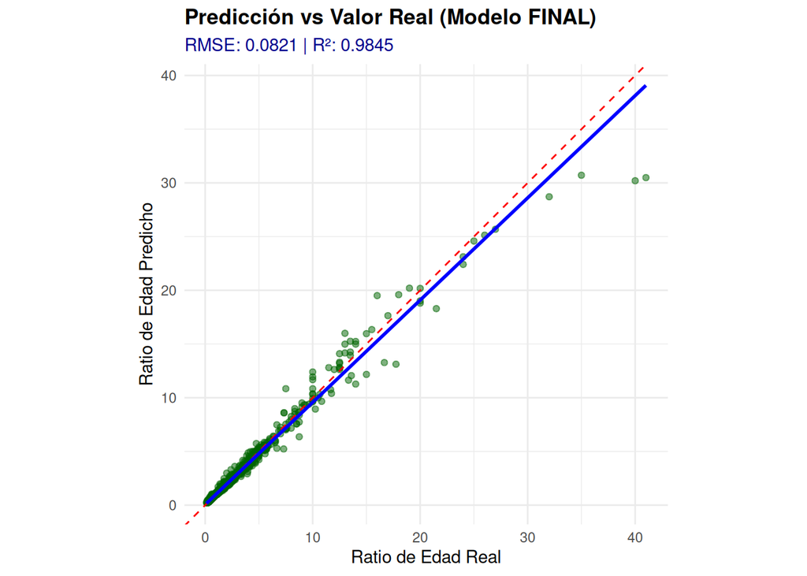

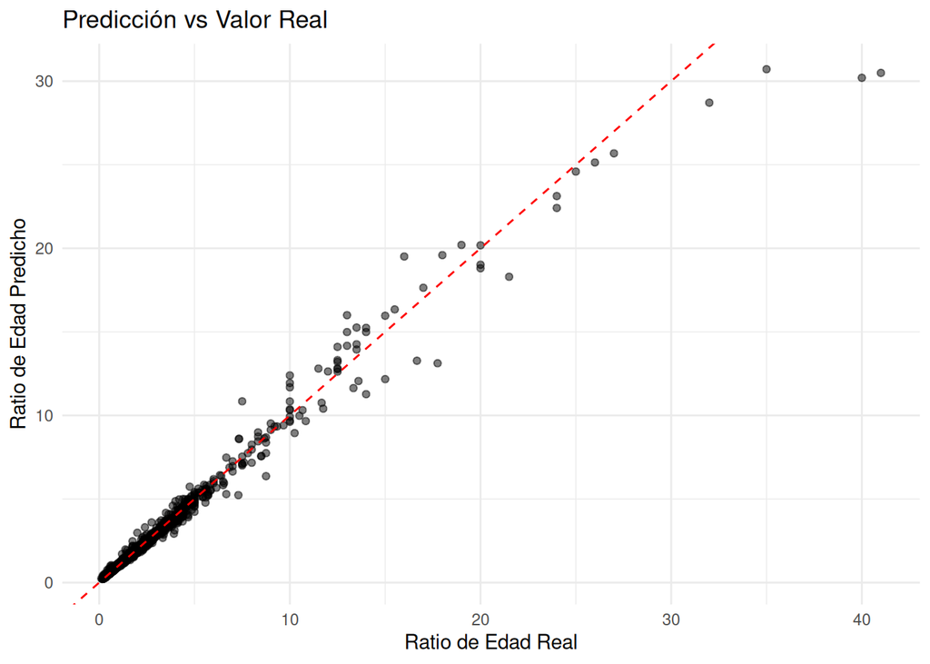

```
## Resumen de importancia de variables (top 5):
```

```
##      VIC_EDAD      AGR_EDAD   VIC_REL_AGR QUIEN_REPORTA    VIC_DEDICA
##     66124.559     13328.694      4614.202      4146.231      1634.844
```

```
## Análisis completado. El modelo final ha sido guardado como 'rf_model_final.rds'
```

Debido a los resultados obtenidos de los 3 modelos iniciales, el Modelo 3 se eligió como el de mejor rendimiento en el conjunto de prueba, con un RMSE de 0.0824 y un R2 de 0.9844. Basándonos en la configuración de hiperparámetros de este modelo, se entrenó un Modelo Final Optimizado, realizando un ligero ajuste al aumentar el número de árboles a 600. La evaluación de este modelo final en el conjunto de prueba resultó en una ligera mejora en las métricas de rendimiento, alcanzando un MAE de 0.0120, un RMSE de 0.0821 y un R2 de 0.9845.

El gráfico de dispersión del modelo final muestra una concentración aún mayor de los puntos alrededor de la línea de predicción perfecta, lo que indica una alta precisión en las predicciones. No obstante, la mejora marginal también indica que el modelo inicial ya se encontraba muy cerca de su máximo potencial con los datos disponibles. En cuanto al sobreajuste, la consistencia en el rendimiento entre el mejor modelo inicial y el modelo final en el conjunto de prueba, incluso con un ligero aumento en la complejidad al añadir más árboles, sugiere que el modelo final generaliza bien a datos no vistos y no presenta signos evidentes de sobreajuste. El alto R2 indica que una gran proporción de la varianza en la variable objetivo es explicada por el modelo, mientras que el bajo RMSE señala que las diferencias entre los valores predichos y reales son pequeñas.